# Commodity Forecasting using Machine Learning

In the past, gold had been used as currency in several countries, including the USA. To ensure the repayment of foreign loans and to limit inflation, which has the effect of revealing a country's financial strength, precious metals like gold are now kept by the central banks of all nations.

Investors may choose the best time to purchase (or sell) gold by predicting the increase and decrease in the daily gold rates.

In this project, we would use the most complete collection of characteristics to estimate gold rates. We would also use a variety of machine learning methods and compare the outcomes. We also pinpoint the characteristics that have a significant impact on gold rates.

### Project Workflow

I would proceed the project as shown in the below mentioned steps

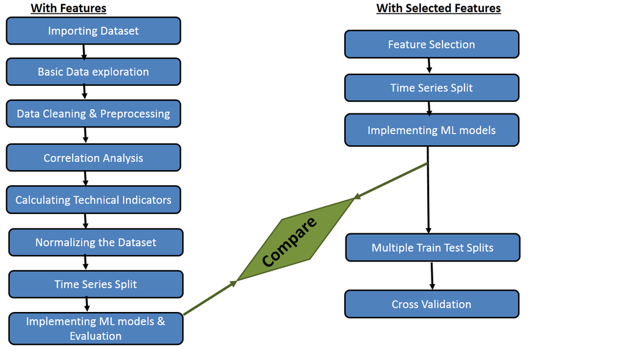

```python
!pip install mercury
```

[output not shown]

[output cut: 57 more lines]

[output not shown]

```python
import mercury as mr
app=mr.App(title="Commodity Forecasting",description="Commodity Forecasting",show_code=False)
```

Mercury Application

This output won't appear in the web app.

```python
!mercury run
```

[output not shown]

#### Importing Libraries

```python
import pandas as pd
import numpy as np
%matplotlib inline
import matplotlib.pyplot as plt
import matplotlib
from sklearn.preprocessing import MinMaxScaler
from sklearn.ensemble import RandomForestRegressor
from matplotlib.pyplot import figure
import seaborn as sns
from sklearn.model_selection import GridSearchCV
from sklearn.model_selection import TimeSeriesSplit
from sklearn.metrics import mean_squared_error, r2_score
import matplotlib.dates as mdates
from sklearn import linear_model
from sklearn.model_selection import TimeSeriesSplit
from sklearn.svm import SVR
```

### About Data

**Attributes:**

**Features:**

- Gold ETF :- Date, Open, High, Low, Close and Volume.
- S&P 500 Index :- 'SP_open', 'SP_high', 'SP_low', 'SP_close', 'SP_Ajclose', 'SP_volume'
- Dow Jones Index :- 'DJ_open','DJ_high', 'DJ_low', 'DJ_close', 'DJ_Ajclose', 'DJ_volume'
- Eldorado Gold Corporation (EGO) :- 'EG_open', 'EG_high', 'EG_low', 'EG_close', 'EG_Ajclose', 'EG_volume'
- EURO - USD Exchange Rate :- 'EU_Price','EU_open', 'EU_high', 'EU_low', 'EU_Trend'
- Brent Crude Oil Futures :- 'OF_Price', 'OF_Open', 'OF_High', 'OF_Low', 'OF_Volume', 'OF_Trend'
- Crude Oil WTI USD :- 'OS_Price', 'OS_Open', 'OS_High', 'OS_Low', 'OS_Trend'
- Silver Futures :- 'SF_Price', 'SF_Open', 'SF_High', 'SF_Low', 'SF_Volume', 'SF_Trend'
- US Bond Rate (10 years) :- 'USB_Price', 'USB_Open', 'USB_High','USB_Low', 'USB_Trend'
- Platinum Price :- 'PLT_Price', 'PLT_Open', 'PLT_High', 'PLT_Low','PLT_Trend'
- Palladium Price :- 'PLD_Price', 'PLD_Open', 'PLD_High', 'PLD_Low','PLD_Trend'
- Rhodium Prices :- 'RHO_PRICE'
- US Dollar Index : 'USDI_Price', 'USDI_Open', 'USDI_High','USDI_Low', 'USDI_Volume', 'USDI_Trend'
- Gold Miners ETF :- 'GDX_Open', 'GDX_High', 'GDX_Low', 'GDX_Close', 'GDX_Adj Close', 'GDX_Volume'
- Oil ETF USO :- 'USO_Open','USO_High', 'USO_Low', 'USO_Close', 'USO_Adj Close', 'USO_Volume'

**Target Variable**

- Gold ETF :- Adjusted Close

```python
data_url = "https://raw.githubusercontent.com/hariomvyas/Commodity-Forecasting/main/Data/FINAL_USO.csv"

df_final = pd.read_csv(data_url,na_values=['null'],index_col='Date',parse_dates=True,infer_datetime_format=True)
```

```python
df_final.head()
```

| Date | Open | High | Low | Close | Adj Close | Volume | SP_open | SP_high | SP_low | SP_close | ... | GDX_Low | GDX_Close | GDX_Adj Close | GDX_Volume | USO_Open | USO_High | USO_Low | USO_Close | USO_Adj Close | USO_Volume |
| --- | --- | --- | --- | --- | --- | --- | --- | --- | --- | --- | --- | --- | --- | --- | --- | --- | --- | --- | --- | --- | --- |
| 2011-12-15 | 154.740005 | 154.949997 | 151.710007 | 152.330002 | 152.330002 | 21521900 | 123.029999 | 123.199997 | 121.989998 | 122.180000 | ... | 51.570000 | 51.680000 | 48.973877 | 20605600 | 36.900002 | 36.939999 | 36.049999 | 36.130001 | 36.130001 | 12616700 |
| 2011-12-16 | 154.309998 | 155.369995 | 153.899994 | 155.229996 | 155.229996 | 18124300 | 122.230003 | 122.949997 | 121.300003 | 121.589996 | ... | 52.040001 | 52.680000 | 49.921513 | 16285400 | 36.180000 | 36.500000 | 35.730000 | 36.270000 | 36.270000 | 12578800 |
| 2011-12-19 | 155.479996 | 155.860001 | 154.360001 | 154.869995 | 154.869995 | 12547200 | 122.059998 | 122.320000 | 120.029999 | 120.290001 | ... | 51.029999 | 51.169998 | 48.490578 | 15120200 | 36.389999 | 36.450001 | 35.930000 | 36.200001 | 36.200001 | 7418200 |
| 2011-12-20 | 156.820007 | 157.429993 | 156.580002 | 156.979996 | 156.979996 | 9136300 | 122.180000 | 124.139999 | 120.370003 | 123.930000 | ... | 52.369999 | 52.990002 | 50.215282 | 11644900 | 37.299999 | 37.610001 | 37.220001 | 37.560001 | 37.560001 | 10041600 |
| 2011-12-21 | 156.979996 | 157.529999 | 156.130005 | 157.160004 | 157.160004 | 11996100 | 123.930000 | 124.360001 | 122.750000 | 124.169998 | ... | 52.419998 | 52.959999 | 50.186852 | 8724300 | 37.669998 | 38.240002 | 37.520000 | 38.110001 | 38.110001 | 10728000 |

5 rows × 80 columns

```python
df_final.shape
```

```
(1718, 80)
```

The dataset contains 1718 entries and 80 columns, including Adjusted Close, our target variable.

```python
df_final.describe()
```

|  | Open | High | Low | Close | Adj Close | Volume | SP_open | SP_high | SP_low | SP_close | ... | GDX_Low | GDX_Close | GDX_Adj Close | GDX_Volume | USO_Open | USO_High | USO_Low | USO_Close | USO_Adj Close | USO_Volume |
| --- | --- | --- | --- | --- | --- | --- | --- | --- | --- | --- | --- | --- | --- | --- | --- | --- | --- | --- | --- | --- | --- |
| count | 1718.000000 | 1718.000000 | 1718.000000 | 1718.000000 | 1718.000000 | 1.718000e+03 | 1718.000000 | 1718.000000 | 1718.000000 | 1718.000000 | ... | 1718.000000 | 1718.000000 | 1718.000000 | 1.718000e+03 | 1718.000000 | 1718.000000 | 1718.000000 | 1718.000000 | 1718.000000 | 1.718000e+03 |
| mean | 127.323434 | 127.854237 | 126.777695 | 127.319482 | 127.319482 | 8.446327e+06 | 204.490023 | 205.372637 | 203.487014 | 204.491222 | ... | 26.384575 | 26.715012 | 25.924624 | 4.356515e+07 | 22.113417 | 22.307148 | 21.904657 | 22.109051 | 22.109051 | 1.922313e+07 |
| std | 17.526993 | 17.631189 | 17.396513 | 17.536269 | 17.536269 | 4.920731e+06 | 43.831928 | 43.974644 | 43.618940 | 43.776999 | ... | 10.490908 | 10.603110 | 9.886570 | 2.909151e+07 | 11.431056 | 11.478671 | 11.373997 | 11.432787 | 11.432787 | 1.575743e+07 |
| min | 100.919998 | 100.989998 | 100.230003 | 100.500000 | 100.500000 | 1.501600e+06 | 122.059998 | 122.320000 | 120.029999 | 120.290001 | ... | 12.400000 | 12.470000 | 12.269618 | 4.729000e+06 | 7.820000 | 8.030000 | 7.670000 | 7.960000 | 7.960000 | 1.035100e+06 |
| 25% | 116.220001 | 116.540001 | 115.739998 | 116.052502 | 116.052502 | 5.412925e+06 | 170.392498 | 170.962506 | 169.577499 | 170.397500 | ... | 20.355000 | 20.585000 | 20.180950 | 2.259968e+07 | 11.420000 | 11.500000 | 11.300000 | 11.392500 | 11.392500 | 6.229500e+06 |
| 50% | 121.915001 | 122.325001 | 121.369999 | 121.795002 | 121.795002 | 7.483900e+06 | 205.464996 | 206.459999 | 204.430000 | 205.529999 | ... | 22.870001 | 23.054999 | 22.677604 | 3.730465e+07 | 16.450000 | 16.635001 | 16.040000 | 16.345000 | 16.345000 | 1.613015e+07 |
| 75% | 128.427494 | 129.087498 | 127.840001 | 128.470001 | 128.470001 | 1.020795e+07 | 237.292500 | 237.722500 | 236.147503 | 236.889996 | ... | 26.797500 | 27.317500 | 26.478154 | 5.697055e+07 | 34.419998 | 34.667499 | 34.110000 | 34.417499 | 34.417499 | 2.672375e+07 |
| max | 173.199997 | 174.070007 | 172.919998 | 173.610001 | 173.610001 | 9.380420e+07 | 293.089996 | 293.940002 | 291.809998 | 293.579987 | ... | 56.770000 | 57.470001 | 54.617039 | 2.321536e+08 | 41.599998 | 42.299999 | 41.299999 | 42.009998 | 42.009998 | 1.102657e+08 |

8 rows × 80 columns

```python
# Checking Missing Values

df_final.isnull().values.any()
```

```
False
```

We dont have any missing values in our dataset.

### Effects of Index prices on gold rates

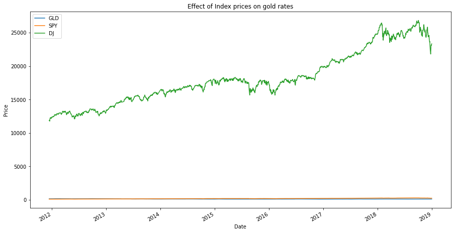

```python
GLD_adj_close = df_final['Adj Close']
SPY_adj_close = df_final['SP_Ajclose']
DJ_adj_close  = df_final['DJ_Ajclose']

df_p = pd.DataFrame({'GLD':GLD_adj_close, 'SPY':SPY_adj_close, 'DJ':DJ_adj_close})

df_ax = df_p.plot(title='Effect of Index prices on gold rates',figsize=(15,8))

df_ax.set_ylabel('Price')
df_ax.legend(loc='upper left')
plt.show()
```

### Computing Daily returns of all Features

```python
def compute_daily_returns(df):
    daily_return = (df / df.shift(1)) - 1
    daily_return[0] = 0
    return daily_return

print("Reference: https://www.kaggle.com/code/sid321axn/gold-price-prediction-using-machine-learning?scriptVersionId=68631508&cellId=21")
```

```
Reference: https://www.kaggle.com/code/sid321axn/gold-price-prediction-using-machine-learning?scriptVersionId=68631508&cellId=21
```

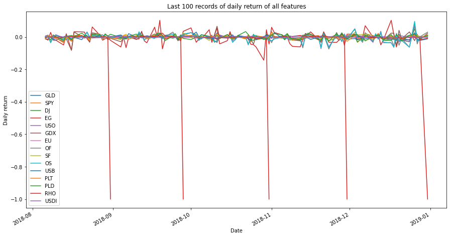

```python
GLD_adj_close = df_final['Adj Close']
SPY_adj_close = df_final['SP_Ajclose']
DJ_adj_close  = df_final['DJ_Ajclose']
EG_adj_close =  df_final['EG_Ajclose']
USO_Adj_close = df_final['USO_Adj Close']
GDX_Adj_close = df_final['GDX_Adj Close']
EU_price      = df_final['EU_Price']
OF_price      = df_final['OF_Price']
OS_price      = df_final['OS_Price']
SF_price      = df_final['SF_Price']
USB_price      = df_final['USB_Price']
PLT_price      = df_final['PLT_Price']
PLD_price      = df_final['PLD_Price']
rho_price      = df_final['RHO_PRICE']
usdi_price      = df_final['USDI_Price']



GLD_daily_return = compute_daily_returns(GLD_adj_close)
SPY_daily_return = compute_daily_returns(SPY_adj_close)
DJ_adj_return    = compute_daily_returns(DJ_adj_close)
EG_adj_return     = compute_daily_returns(EG_adj_close)
USO_Adj_return    = compute_daily_returns(USO_Adj_close)
GDX_Adj_return   =compute_daily_returns(GDX_Adj_close)
EU_return        = compute_daily_returns(EU_price)
OF_price         =compute_daily_returns(OF_price)
OS_price         =compute_daily_returns(OS_price)
SF_price         =compute_daily_returns(SF_price)
USB_price         =compute_daily_returns(USB_price)
PLT_price         =compute_daily_returns(PLT_price)
PLD_price         =compute_daily_returns(PLD_price)
rho_price         =compute_daily_returns(rho_price)
USDI_price         =compute_daily_returns(usdi_price)

df_d = pd.DataFrame({'GLD':GLD_daily_return, 'SPY':SPY_daily_return, 'DJ':DJ_adj_return, 'EG':EG_adj_return, 'USO':USO_Adj_return,
                  'GDX':GDX_Adj_return,'EU':EU_return, 'OF':OF_price,'SF':SF_price,'OS':OS_price, 'USB':USB_price, 'PLT':PLT_price, 'PLD':PLD_price,
                  'RHO':rho_price,'USDI':USDI_price})

daily_ax = df_d[-100:].plot(title='Last 100 records of daily return of all features',figsize=(15,8))

daily_ax.set_ylabel('Daily return')
daily_ax.legend(loc='lower left')
plt.show()
```

### Computing daily returns of stock indexes

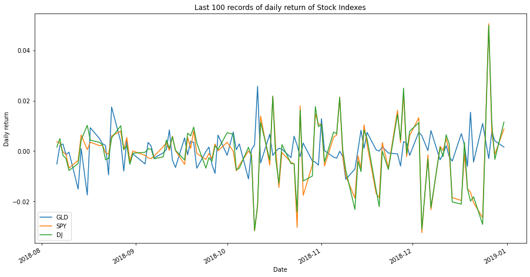

```python
df_s = pd.DataFrame({'GLD':GLD_daily_return, 'SPY':SPY_daily_return, 'DJ':DJ_adj_return})

daily_ax = df_s[-100:].plot(title='Last 100 records of daily return of Stock Indexes',figsize=(15,8))

daily_ax.set_ylabel('Daily return')
daily_ax.legend(loc='lower left')
plt.show()
```

### Scatter Plot

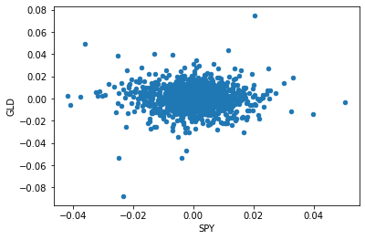

```python
df_d.plot(kind='scatter', x='SPY', y='GLD')
```

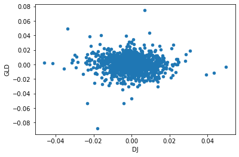

```python
df_d.plot(kind='scatter', x='DJ', y='GLD')
```

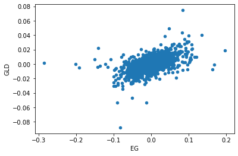

```python
df_d.plot(kind='scatter', x='EG', y='GLD')
```

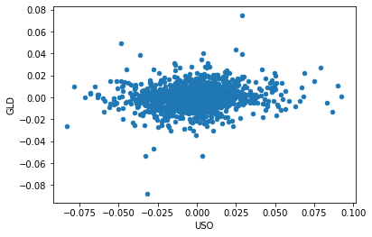

```python
df_d.plot(kind='scatter', x='USO', y='GLD')
```

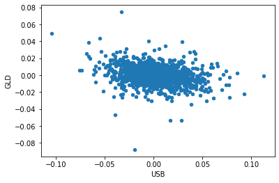

```python
df_d.plot(kind='scatter', x='USB', y='GLD')
```

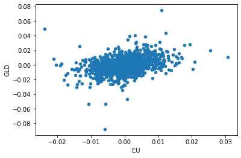

```python
df_d.plot(kind='scatter', x='EU', y='GLD')
```

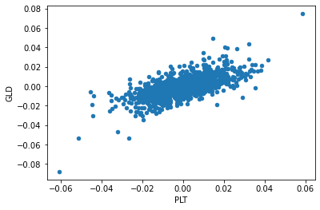

```python
df_d.plot(kind='scatter', x='PLT', y='GLD')
```

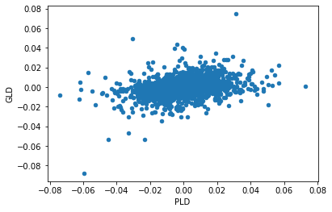

```python
df_d.plot(kind='scatter', x='PLD', y='GLD')
```

### Statistical Measures (Mean, Standard Deviation, Kurtosis)

**Kurtosis** is a statistical measure that is used to describe the distribution. Whereas skewness differentiates extreme values in one versus the other tail, kurtosis measures extreme values in either tail. Distributions with large kurtosis exhibit tail data exceeding the tails of the normal distribution (e.g., five or more standard deviations from the mean). Distributions with low kurtosis exhibit tail data that is generally less extreme than the tails of the normal distribution.

For investors, high kurtosis of the return distribution implies that the investor will experience occasional extreme returns (either positive or negative), more extreme than the usual + or - three standard deviations from the mean that is predicted by the normal distribution of returns. This phenomenon is known as **kurtosis risk**.

**Positive Kurtosis** More weights in the tail

**Negative Kurtosis** It has as much data in each tail as it does in the peak.

```
Mean= -8.65698612128203e-05
Standard Deviation= 0.009611536167006381
Kurtosis= 8.606584924918355
```

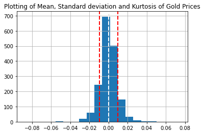

```python
# computing mean,standard deviation and kurtosis of Gold ETF daily return

mean=df_d['GLD'].mean()
# computing standard deviation of Gold stock
std=df_d['GLD'].std()
kurt=df_d['GLD'].kurtosis()
print('Mean=',mean)
print('Standard Deviation=',std)
print('Kurtosis=',kurt)
#Plotting Histogram
df_d['GLD'].hist(bins=20)

plt.axvline(mean, color='w',linestyle='dashed',linewidth=2)
plt.axvline(std, color='r',linestyle='dashed',linewidth=2)
plt.axvline(-std, color='r',linestyle='dashed',linewidth=2)
plt.title("Plotting of Mean, Standard deviation and Kurtosis of Gold Prices")
plt.show()
```

```
Mean= 0.0005366024364688835
Standard Deviation= 0.008262309911393526
Kurtosis= 3.4557859039745233
```

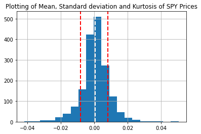

```python
# computing mean,standard deviation and kurtosis of S&P 500 Index daily return

mean=df_d['SPY'].mean()
# computing standard deviation of Gold stock
std=df_d['SPY'].std()
kurt=df_d['SPY'].kurtosis()
print('Mean=',mean)
print('Standard Deviation=',std)
print('Kurtosis=',kurt)
#Plotting Histogram
df_d['SPY'].hist(bins=20)

plt.axvline(mean, color='w',linestyle='dashed',linewidth=2)
plt.axvline(std, color='r',linestyle='dashed',linewidth=2)
plt.axvline(-std, color='r',linestyle='dashed',linewidth=2)
plt.title("Plotting of Mean, Standard deviation and Kurtosis of SPY Prices")
plt.show()
```

```
Mean= 0.0004266395218751805
Standard Deviation= 0.008151780114512303
Kurtosis= 3.832719336260695
```

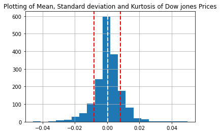

```python
# computing mean,standard deviation and kurtosis of Dow Jones Index daily return
mean=df_d['DJ'].mean()
# computing standard deviation of Gold stock
std=df_d['DJ'].std()
kurt=df_d['DJ'].kurtosis()
print('Mean=',mean)
print('Standard Deviation=',std)
print('Kurtosis=',kurt)
#Plotting Histogram
df_d['DJ'].hist(bins=20)

plt.axvline(mean, color='w',linestyle='dashed',linewidth=2)
plt.axvline(std, color='r',linestyle='dashed',linewidth=2)
plt.axvline(-std, color='r',linestyle='dashed',linewidth=2)
plt.title("Plotting of Mean, Standard deviation and Kurtosis of Dow jones Prices")
plt.show()
```

## Correlation Analysis

#### Plotting Correlation Matrix

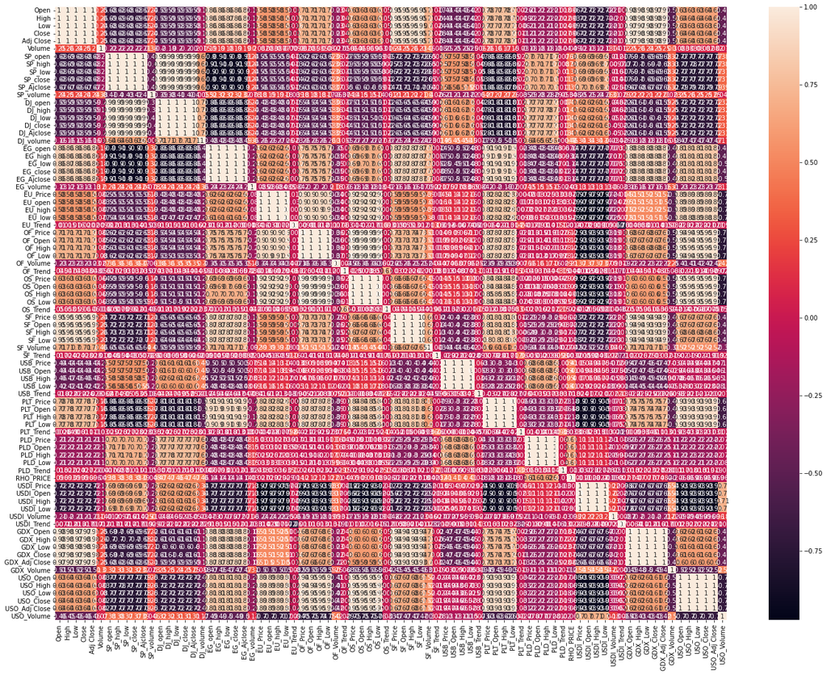

```python
plt.figure(figsize=(24,18))
sns.heatmap(df_final.corr(), annot=True)
```

```python
X=df_final.drop(['Adj Close'],axis=1)
X=X.drop(['Close'],axis=1)
```

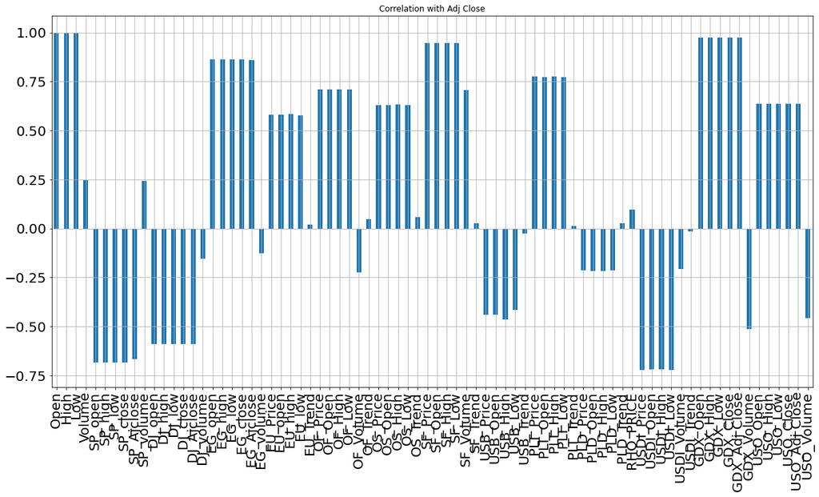

```python
X.corrwith(df_final['Adj Close']).plot.bar(
        figsize = (20, 10), title = "Correlation with Adj Close", fontsize = 20,
        rot = 90, grid = True)
```

```python
corr_matrix=df_final.corr()
coef=corr_matrix["Adj Close"].sort_values(ascending=False)
```

#### Positively Correlated Variables

```python
pos_corr=coef[coef>0]
pos_corr
```

```
Close            1.000000
Adj Close        1.000000
High             0.999535
Low              0.999532
Open             0.998976
GDX_Low          0.975561
GDX_Close        0.975459
GDX_High         0.975255
GDX_Adj Close    0.974980
GDX_Open         0.974824
SF_Low           0.947842
SF_Price         0.947420
SF_Open          0.945557
SF_High          0.945203
EG_low           0.863917
EG_open          0.862900
EG_close         0.862770
EG_high          0.861479
EG_Ajclose       0.859850
PLT_Price        0.775861
PLT_High         0.775481
PLT_Low          0.773993
PLT_Open         0.773760
OF_High          0.711334
OF_Price         0.710693
OF_Open          0.709096
OF_Low           0.708266
SF_Volume        0.706505
USO_Adj Close    0.635675
USO_Close        0.635675
USO_High         0.635311
USO_Open         0.635197
USO_Low          0.634732
OS_High          0.632001
OS_Price         0.630817
OS_Open          0.630046
OS_Low           0.629083
EU_high          0.582969
EU_Price         0.581036
EU_open          0.579036
EU_low           0.577000
Volume           0.246778
SP_volume        0.241949
RHO_PRICE        0.095782
OS_Trend         0.059510
OF_Trend         0.048205
SF_Trend         0.028100
PLD_Trend        0.026536
EU_Trend         0.019913
PLT_Trend        0.011355
Name: Adj Close, dtype: float64
```

#### Negatively Correlated Varibales

```python
neg_corr=coef[coef<0]
neg_corr
```

```
USDI_Trend    -0.016641
USB_Trend     -0.025933
EG_volume     -0.126586
DJ_volume     -0.155526
USDI_Volume   -0.205954
PLD_Price     -0.213179
PLD_Low       -0.214919
PLD_Open      -0.216426
PLD_High      -0.217490
OF_Volume     -0.225436
USB_Low       -0.417352
USB_Open      -0.440822
USB_Price     -0.441347
USO_Volume    -0.456193
USB_High      -0.464116
GDX_Volume    -0.514616
DJ_low        -0.588157
DJ_Ajclose    -0.588411
DJ_close      -0.588411
DJ_high       -0.588778
DJ_open       -0.588800
SP_Ajclose    -0.666071
SP_low        -0.683750
SP_close      -0.684284
SP_open       -0.684618
SP_high       -0.684904
USDI_High     -0.720023
USDI_Open     -0.720140
USDI_Price    -0.721569
USDI_Low      -0.722078
Name: Adj Close, dtype: float64
```

### Technical Indicators

We will also use following technical indicators which I feel help as a feature for prediction of Gold price

1. MACD : The moving average convergence-divergence (MACD) is one of the most powerful and well-known indicators in technical analysis. The indicator is comprised of two exponential moving averages that help measure momentum in a security. The MACD is simply the difference between these two moving averages plotted against a centerline, where the centerline is the point at which the two moving averages are equal.
2. RSI : The relative strength index (RSI) is another well known momentum indicators that’s widely used in technical analysis. The indicator is commonly used to identify overbought and oversold conditions in a security with a range between 0 (oversold) and 100 (overbought).
3. Simple Moving Average (SMA) : simply takes the sum of all of the past closing prices over a time period and divides the result by the total number of prices used in the calculation. For example, a 10-day simple moving average takes the last ten closing prices and divides them by ten.
4. Upper Band
5. Lower Band
6. DIFF
7. Open-Close
8. High-Low

```python
def calculate_MACD(df, nslow=26, nfast=12):
    emaslow = df.ewm(span=nslow, min_periods=nslow, adjust=True, ignore_na=False).mean()
    emafast = df.ewm(span=nfast, min_periods=nfast, adjust=True, ignore_na=False).mean()
    dif = emafast - emaslow
    MACD = dif.ewm(span=9, min_periods=9, adjust=True, ignore_na=False).mean()
    return dif, MACD

def calculate_RSI(df, periods=14):
    # wilder's RSI
    delta = df.diff()
    up, down = delta.copy(), delta.copy()

    up[up < 0] = 0
    down[down > 0] = 0

    rUp = up.ewm(com=periods,adjust=False).mean()
    rDown = down.ewm(com=periods, adjust=False).mean().abs()

    rsi = 100 - 100 / (1 + rUp / rDown)
    return rsi

def calculate_SMA(df, peroids=15):
    SMA = df.rolling(window=peroids, min_periods=peroids, center=False).mean()
    return SMA

def calculate_BB(df, peroids=15):
    STD = df.rolling(window=peroids,min_periods=peroids, center=False).std()
    SMA = calculate_SMA(df)
    upper_band = SMA + (2 * STD)
    lower_band = SMA - (2 * STD)
    return upper_band, lower_band

def calculate_stdev(df,periods=5):
    STDEV = df.rolling(periods).std()
    return STDEV
```

#### Plotting Technical Indicators

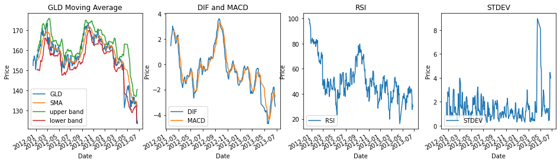

```python
fig, axes = plt.subplots(nrows=1, ncols=4, figsize=(16, 4))

# Calculate Simple Moving Average for GLD
SMA_GLD = calculate_SMA(GLD_adj_close)

GLD_adj_close[:365].plot(title='GLD Moving Average',label='GLD', ax=axes[0])

SMA_GLD[:365].plot(label="SMA",ax=axes[0])


# Calculate Bollinger Bands for GLD
upper_band, lower_band = calculate_BB(GLD_adj_close)

upper_band[:365].plot(label='upper band', ax=axes[0])
lower_band[:365].plot(label='lower band', ax=axes[0])


# Calculate MACD for GLD
DIF, MACD = calculate_MACD(GLD_adj_close)

DIF[:365].plot(title='DIF and MACD',label='DIF', ax=axes[1])
MACD[:365].plot(label='MACD', ax=axes[1])

# Calculate RSI for GLD
RSI = calculate_RSI(GLD_adj_close)
RSI[:365].plot(title='RSI',label='RSI', ax=axes[2])

# Calculating Standard deviation for GLD
STDEV= calculate_stdev(GLD_adj_close)
STDEV[:365].plot(title='STDEV',label='STDEV', ax=axes[3])

Open_Close=df_final.Open - df_final.Close

High_Low=df_final.High-df_final.Low

axes[0].set_ylabel('Price')
axes[1].set_ylabel('Price')
axes[2].set_ylabel('Price')
axes[3].set_ylabel('Price')



axes[0].legend(loc='lower left')
axes[1].legend(loc='lower left')
axes[2].legend(loc='lower left')
axes[3].legend(loc='lower left')
```

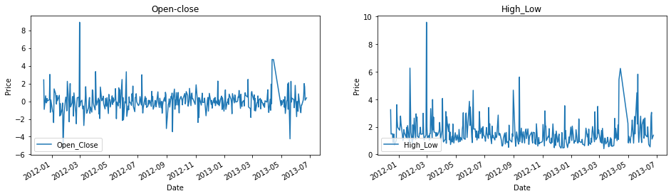

```python
fig, axes = plt.subplots(nrows=1, ncols=2, figsize=(16, 4))
Open_Close=df_final.Open - df_final.Close
Open_Close[:365].plot(title='Open-close',label='Open_Close', ax=axes[0])

High_Low=df_final.High-df_final.Low
High_Low[:365].plot(title='High_Low',label='High_Low', ax=axes[1])
axes[0].set_ylabel('Price')
axes[1].set_ylabel('Price')
axes[0].legend(loc='lower left')
axes[1].legend(loc='lower left')
```

```python
test = df_final
test['SMA'] = SMA_GLD
test['Upper_band'] = upper_band
test['Lower_band'] = lower_band
test['DIF'] = DIF
test['MACD'] = MACD
test['RSI'] = RSI
test['STDEV'] = STDEV
test['Open_Close']=Open_Close
test['High_Low']=High_Low


# Dropping first 33 records from the data as it has null values because of introduction of technical indicators
test = test[33:]

# Target column
target_adj_close = pd.DataFrame(test['Adj Close'])


display(test.head())
```

| Date | Open | High | Low | Close | Adj Close | Volume | SP_open | SP_high | SP_low | SP_close | ... | USO_Volume | SMA | Upper_band | Lower_band | DIF | MACD | RSI | STDEV | Open_Close | High_Low |
| --- | --- | --- | --- | --- | --- | --- | --- | --- | --- | --- | --- | --- | --- | --- | --- | --- | --- | --- | --- | --- | --- |
| 2012-02-06 | 166.960007 | 167.679993 | 166.610001 | 167.179993 | 167.179993 | 8807400 | 133.979996 | 134.509995 | 133.830002 | 134.449997 | ... | 6126100 | 165.198666 | 173.018365 | 157.378968 | 2.724443 | 2.641891 | 70.144545 | 1.562107 | -0.219986 | 1.069992 |
| 2012-02-07 | 167.380005 | 170.089996 | 167.149994 | 169.699997 | 169.699997 | 11614300 | 134.169998 | 135.020004 | 133.639999 | 134.789993 | ... | 10237000 | 165.894667 | 173.296304 | 158.493029 | 2.754381 | 2.667095 | 73.152763 | 1.594111 | -2.319992 | 2.940002 |
| 2012-02-08 | 169.259995 | 169.960007 | 167.500000 | 168.500000 | 168.500000 | 10655500 | 134.860001 | 135.220001 | 134.309998 | 135.190002 | ... | 9045800 | 166.428000 | 173.297467 | 159.558533 | 2.655845 | 2.664634 | 69.576023 | 1.575718 | 0.759995 | 2.460007 |
| 2012-02-09 | 170.009995 | 170.369995 | 167.669998 | 168.020004 | 168.020004 | 16085200 | 135.410004 | 135.589996 | 134.559998 | 135.360001 | ... | 4663500 | 166.856000 | 173.217507 | 160.494493 | 2.511947 | 2.631843 | 68.148015 | 0.965153 | 1.989991 | 2.699997 |
| 2012-02-10 | 166.490005 | 167.639999 | 166.330002 | 167.139999 | 167.139999 | 10326800 | 134.160004 | 134.470001 | 133.839996 | 134.360001 | ... | 6008600 | 167.250666 | 172.795817 | 161.705515 | 2.303734 | 2.562404 | 65.507009 | 1.059963 | -0.649994 | 1.309997 |

5 rows × 89 columns

```python
df_final.columns
```

```
Index(['Open', 'High', 'Low', 'Close', 'Adj Close', 'Volume', 'SP_open',
       'SP_high', 'SP_low', 'SP_close', 'SP_Ajclose', 'SP_volume', 'DJ_open',
       'DJ_high', 'DJ_low', 'DJ_close', 'DJ_Ajclose', 'DJ_volume', 'EG_open',
       'EG_high', 'EG_low', 'EG_close', 'EG_Ajclose', 'EG_volume', 'EU_Price',
       'EU_open', 'EU_high', 'EU_low', 'EU_Trend', 'OF_Price', 'OF_Open',
       'OF_High', 'OF_Low', 'OF_Volume', 'OF_Trend', 'OS_Price', 'OS_Open',
       'OS_High', 'OS_Low', 'OS_Trend', 'SF_Price', 'SF_Open', 'SF_High',
       'SF_Low', 'SF_Volume', 'SF_Trend', 'USB_Price', 'USB_Open', 'USB_High',
       'USB_Low', 'USB_Trend', 'PLT_Price', 'PLT_Open', 'PLT_High', 'PLT_Low',
       'PLT_Trend', 'PLD_Price', 'PLD_Open', 'PLD_High', 'PLD_Low',
       'PLD_Trend', 'RHO_PRICE', 'USDI_Price', 'USDI_Open', 'USDI_High',
       'USDI_Low', 'USDI_Volume', 'USDI_Trend', 'GDX_Open', 'GDX_High',
       'GDX_Low', 'GDX_Close', 'GDX_Adj Close', 'GDX_Volume', 'USO_Open',
       'USO_High', 'USO_Low', 'USO_Close', 'USO_Adj Close', 'USO_Volume',
       'SMA', 'Upper_band', 'Lower_band', 'DIF', 'MACD', 'RSI', 'STDEV',
       'Open_Close', 'High_Low'],
      dtype='object')
```

Next, we will segregate feature and target variables. We will not use Close feature of GLD ETF and will use Adjusted Close of GOLD ETF as a target variables

```python
# selecting Feature Columns
feature_columns = ['Open', 'High', 'Low', 'Volume','SP_open','SP_high','SP_low','SP_Ajclose','SP_volume','DJ_open','DJ_high', 'DJ_low',  'DJ_Ajclose', 'DJ_volume', 'EG_open','EG_high', 'EG_low',
                   'EG_Ajclose', 'EG_volume', 'EU_Price','EU_open', 'EU_high', 'EU_low', 'EU_Trend', 'OF_Price','OF_Open','OF_High', 'OF_Low', 'OF_Volume', 'OF_Trend', 'OS_Price', 'OS_Open','OS_High', 'OS_Low', 'OS_Trend', 'SF_Price', 'SF_Open', 'SF_High',
                   'SF_Low', 'SF_Volume', 'SF_Trend', 'USB_Price', 'USB_Open', 'USB_High','USB_Low', 'USB_Trend', 'PLT_Price', 'PLT_Open', 'PLT_High', 'PLT_Low',
                    'PLT_Trend', 'PLD_Price', 'PLD_Open', 'PLD_High', 'PLD_Low','PLD_Trend', 'RHO_PRICE', 'USDI_Price', 'USDI_Open', 'USDI_High',
                     'USDI_Low', 'USDI_Volume', 'USDI_Trend','GDX_Open', 'GDX_High',
       'GDX_Low', 'GDX_Close', 'GDX_Adj Close', 'GDX_Volume', 'USO_Open',
       'USO_High', 'USO_Low', 'USO_Close', 'USO_Adj Close', 'USO_Volume','SMA', 'Upper_band', 'Lower_band', 'DIF', 'MACD','RSI','STDEV','Open_Close', 'High_Low']
```

#### Normalizing the data

In this step, we will perform feature scaling/normalization of feature variables using sklearn's MinMaxScaler function

```python
from sklearn.preprocessing import MinMaxScaler
scaler = MinMaxScaler()
feature_minmax_transform_data = scaler.fit_transform(test[feature_columns])
feature_minmax_transform = pd.DataFrame(columns=feature_columns, data=feature_minmax_transform_data, index=test.index)
feature_minmax_transform.head()
```

| Date | Open | High | Low | Volume | SP_open | SP_high | SP_low | SP_Ajclose | SP_volume | DJ_open | ... | USO_Volume | SMA | Upper_band | Lower_band | DIF | MACD | RSI | STDEV | Open_Close | High_Low |
| --- | --- | --- | --- | --- | --- | --- | --- | --- | --- | --- | --- | --- | --- | --- | --- | --- | --- | --- | --- | --- | --- |
| 2012-02-06 | 0.913669 | 0.912561 | 0.913193 | 0.079151 | 0.037098 | 0.034927 | 0.040627 | 0.028113 | 0.166542 | 0.051563 | ... | 0.046608 | 0.906189 | 0.961240 | 0.821988 | 0.893394 | 0.911893 | 0.807275 | 0.167603 | 0.415010 | 0.091684 |
| 2012-02-07 | 0.919480 | 0.945539 | 0.920622 | 0.109560 | 0.038247 | 0.038015 | 0.039473 | 0.029765 | 0.224602 | 0.050453 | ... | 0.084243 | 0.916193 | 0.965092 | 0.837893 | 0.896986 | 0.915193 | 0.852413 | 0.171198 | 0.280308 | 0.291045 |
| 2012-02-08 | 0.945490 | 0.943760 | 0.925437 | 0.099173 | 0.042423 | 0.039225 | 0.043542 | 0.031707 | 0.232599 | 0.051907 | ... | 0.073338 | 0.923859 | 0.965108 | 0.853105 | 0.885164 | 0.914871 | 0.798744 | 0.169132 | 0.477870 | 0.239873 |
| 2012-02-09 | 0.955866 | 0.949370 | 0.927775 | 0.157998 | 0.045752 | 0.041465 | 0.045060 | 0.032533 | 0.251876 | 0.053171 | ... | 0.033218 | 0.930011 | 0.964000 | 0.866467 | 0.867900 | 0.910578 | 0.777317 | 0.100533 | 0.556766 | 0.265458 |
| 2012-02-10 | 0.907167 | 0.912014 | 0.909341 | 0.095612 | 0.038187 | 0.034685 | 0.040687 | 0.027676 | 0.292146 | 0.053519 | ... | 0.045532 | 0.935684 | 0.958155 | 0.883757 | 0.842920 | 0.901486 | 0.737688 | 0.111185 | 0.387428 | 0.117271 |

5 rows × 84 columns

```python
display(feature_minmax_transform.head())
print('Shape of features : ', feature_minmax_transform.shape)
print('Shape of target : ', target_adj_close.shape)

# Shift target array because we want to predict the n + 1 day value


target_adj_close = target_adj_close.shift(-1)
validation_y = target_adj_close[-90:-1]
target_adj_close = target_adj_close[:-90]

# Taking last 90 rows of data to be validation set
validation_X = feature_minmax_transform[-90:-1]
feature_minmax_transform = feature_minmax_transform[:-90]
display(validation_X.tail())
display(validation_y.tail())

print("\n -----After process------ \n")
print('Shape of features : ', feature_minmax_transform.shape)
print('Shape of target : ', target_adj_close.shape)
display(target_adj_close.tail())
```

| Date | Open | High | Low | Volume | SP_open | SP_high | SP_low | SP_Ajclose | SP_volume | DJ_open | ... | USO_Volume | SMA | Upper_band | Lower_band | DIF | MACD | RSI | STDEV | Open_Close | High_Low |
| --- | --- | --- | --- | --- | --- | --- | --- | --- | --- | --- | --- | --- | --- | --- | --- | --- | --- | --- | --- | --- | --- |
| 2012-02-06 | 0.913669 | 0.912561 | 0.913193 | 0.079151 | 0.037098 | 0.034927 | 0.040627 | 0.028113 | 0.166542 | 0.051563 | ... | 0.046608 | 0.906189 | 0.961240 | 0.821988 | 0.893394 | 0.911893 | 0.807275 | 0.167603 | 0.415010 | 0.091684 |
| 2012-02-07 | 0.919480 | 0.945539 | 0.920622 | 0.109560 | 0.038247 | 0.038015 | 0.039473 | 0.029765 | 0.224602 | 0.050453 | ... | 0.084243 | 0.916193 | 0.965092 | 0.837893 | 0.896986 | 0.915193 | 0.852413 | 0.171198 | 0.280308 | 0.291045 |
| 2012-02-08 | 0.945490 | 0.943760 | 0.925437 | 0.099173 | 0.042423 | 0.039225 | 0.043542 | 0.031707 | 0.232599 | 0.051907 | ... | 0.073338 | 0.923859 | 0.965108 | 0.853105 | 0.885164 | 0.914871 | 0.798744 | 0.169132 | 0.477870 | 0.239873 |
| 2012-02-09 | 0.955866 | 0.949370 | 0.927775 | 0.157998 | 0.045752 | 0.041465 | 0.045060 | 0.032533 | 0.251876 | 0.053171 | ... | 0.033218 | 0.930011 | 0.964000 | 0.866467 | 0.867900 | 0.910578 | 0.777317 | 0.100533 | 0.556766 | 0.265458 |
| 2012-02-10 | 0.907167 | 0.912014 | 0.909341 | 0.095612 | 0.038187 | 0.034685 | 0.040687 | 0.027676 | 0.292146 | 0.053519 | ... | 0.045532 | 0.935684 | 0.958155 | 0.883757 | 0.842920 | 0.901486 | 0.737688 | 0.111185 | 0.387428 | 0.117271 |

5 rows × 84 columns

```
Shape of features :  (1685, 84)
Shape of target :  (1685, 1)
```

| Date | Open | High | Low | Volume | SP_open | SP_high | SP_low | SP_Ajclose | SP_volume | DJ_open | ... | USO_Volume | SMA | Upper_band | Lower_band | DIF | MACD | RSI | STDEV | Open_Close | High_Low |
| --- | --- | --- | --- | --- | --- | --- | --- | --- | --- | --- | --- | --- | --- | --- | --- | --- | --- | --- | --- | --- | --- |
| 2018-12-21 | 0.252767 | 0.249863 | 0.252304 | 0.131396 | 0.719499 | 0.732264 | 0.685249 | 0.721173 | 0.474541 | 0.731087 | ... | 0.346662 | 0.221370 | 0.217009 | 0.228105 | 0.658641 | 0.648503 | 0.687759 | 0.071990 | 0.459268 | 0.050107 |
| 2018-12-24 | 0.258024 | 0.262042 | 0.266061 | 0.089215 | 0.672900 | 0.678571 | 0.650574 | 0.685607 | 0.249183 | 0.693452 | ... | 0.188254 | 0.225663 | 0.221905 | 0.231591 | 0.673309 | 0.655308 | 0.771343 | 0.103731 | 0.400256 | 0.038380 |
| 2018-12-26 | 0.272551 | 0.273810 | 0.266061 | 0.138587 | 0.654321 | 0.710896 | 0.647477 | 0.751818 | 0.397651 | 0.662258 | ... | 0.365682 | 0.228778 | 0.225424 | 0.234153 | 0.680140 | 0.662243 | 0.728779 | 0.105509 | 0.490699 | 0.130064 |
| 2018-12-27 | 0.271859 | 0.272441 | 0.273903 | 0.112378 | 0.694263 | 0.723668 | 0.679055 | 0.762387 | 0.330444 | 0.714615 | ... | 0.325400 | 0.232083 | 0.233069 | 0.232846 | 0.692906 | 0.670576 | 0.782400 | 0.071859 | 0.429121 | 0.058636 |
| 2018-12-28 | 0.275042 | 0.274904 | 0.281882 | 0.058103 | 0.736686 | 0.742494 | 0.724540 | 0.760598 | 0.261258 | 0.754292 | ... | 0.199288 | 0.235840 | 0.241125 | 0.232010 | 0.706157 | 0.680136 | 0.808642 | 0.092629 | 0.412444 | 0.015992 |

5 rows × 84 columns

| Date | Adj Close |
| --- | --- |
| 2018-12-21 | 120.019997 |
| 2018-12-24 | 119.660004 |
| 2018-12-26 | 120.570000 |
| 2018-12-27 | 121.059998 |
| 2018-12-28 | 121.250000 |

```
 -----After process------

Shape of features :  (1595, 84)
Shape of target :  (1595, 1)
```

| Date | Adj Close |
| --- | --- |
| 2018-08-13 | 113.070000 |
| 2018-08-14 | 111.099998 |
| 2018-08-16 | 112.129997 |
| 2018-08-17 | 112.690002 |
| 2018-08-20 | 113.019997 |

### Train Test Split

In this step we will perform Train-Test split using sklearn's Timeseries split

```python
ts_split= TimeSeriesSplit(n_splits=10)
for train_index, test_index in ts_split.split(feature_minmax_transform):
        X_train, X_test = feature_minmax_transform[:len(train_index)], feature_minmax_transform[len(train_index): (len(train_index)+len(test_index))]
        y_train, y_test = target_adj_close[:len(train_index)].values.ravel(), target_adj_close[len(train_index): (len(train_index)+len(test_index))].values.ravel()
```

```python
X_train.shape
```

```
(1450, 84)
```

```python
X_test.shape
```

```
(145, 84)
```

```python
y_train.shape
```

```
(1450,)
```

```python
y_test.shape
```

```
(145,)
```

```python
def validate_result(model, model_name):
    predicted = model.predict(validation_X)
    RSME_score = np.sqrt(mean_squared_error(validation_y, predicted))
    print('RMSE: ', RSME_score)

    R2_score = r2_score(validation_y, predicted)
    print('R2 score: ', R2_score)

    plt.plot(validation_y.index, predicted,'r', label='Predict')
    plt.plot(validation_y.index, validation_y,'b', label='Actual')
    plt.ylabel('Price')
    plt.gca().xaxis.set_major_formatter(mdates.DateFormatter('%Y-%m-%d'))
    plt.gca().xaxis.set_major_locator(mdates.MonthLocator())
    plt.title(model_name + ' Predict vs Actual')
    plt.legend(loc='upper right')
    plt.show()
```

## Model Building

### Decision Tree Regressor

It is considered to be a Benchmark model

```
RMSE:  1.2166871700124942
R2 score:  0.6590361406118342
```

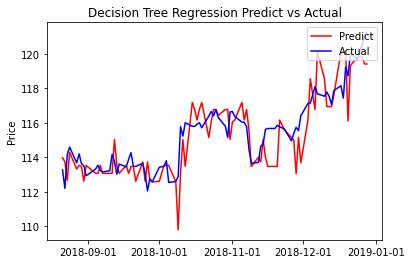

```python
from sklearn.tree import DecisionTreeRegressor

dt = DecisionTreeRegressor(random_state=0)

benchmark_dt=dt.fit(X_train, y_train)

validate_result(benchmark_dt, 'Decision Tree Regression')
```

### Support Vector Regressor (SVR)

```
RMSE:  0.8136915781867415
R2 score:  0.8474998982808452
```

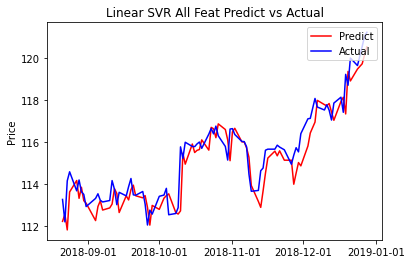

```python
# Save all soultion models
solution_models = {}
# SVR with  linear Kernel
svr_lin = SVR(kernel='linear')
linear_svr_clf_feat = svr_lin.fit(X_train,y_train)
validate_result(linear_svr_clf_feat,'Linear SVR All Feat')
```

#### Hyper Parameter Tuning

We will tune two parameters of SVR and Epsilon to see if the model shows any improvement

```
RMSE:  0.741776670609294
R2 score:  0.8732649232942415
```

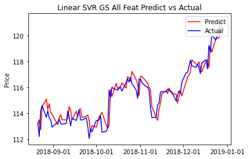

```python
linear_svr_parameters = {
    'C':[0.5, 1.0, 10.0, 50.0],
    'epsilon':[0, 0.1, 0.5, 0.7, 0.9],
}

lsvr_grid_search_feat = GridSearchCV(estimator=linear_svr_clf_feat,
                           param_grid=linear_svr_parameters,
                           cv=ts_split,
)

lsvr_grid_search_feat.fit(X_train, y_train)

validate_result(lsvr_grid_search_feat,'Linear SVR GS All Feat')
```

As we have seen using gridsearch on SVR we get significant improvement in R2 score and RMSE also came down so we will save this as our first solution model

```python
solution_models['SVR All Feat'] = lsvr_grid_search_feat
```

### Random Forest

```
RMSE:  0.8078828885891266
R2 score:  0.8496694277726002
```

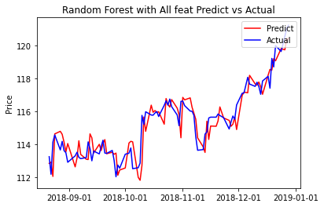

```python
rf_cl = RandomForestRegressor(n_estimators=50, random_state=0)
random_forest_clf_feat = rf_cl.fit(X_train,y_train)
validate_result(random_forest_clf_feat,'Random Forest with All feat')
```

#### Hyper parameter Tuning

We will tune 3 parameters of Random Forest which are n_estimators, max_features, max_depth

```python
random_forest_parameters = {
    'n_estimators':[10,15,20, 50, 100],
    'max_features':['auto','sqrt','log2'],
    'max_depth':[2, 3, 5, 7,10],
}

grid_search_RF_feat = GridSearchCV(estimator=random_forest_clf_feat,
                           param_grid=random_forest_parameters,
                           cv=ts_split,
)

grid_search_RF_feat.fit(X_train, y_train)
```

```
GridSearchCV(cv=TimeSeriesSplit(gap=0, max_train_size=None, n_splits=10, test_size=None),
             estimator=RandomForestRegressor(n_estimators=50, random_state=0),
             param_grid={'max_depth': [2, 3, 5, 7, 10],
                         'max_features': ['auto', 'sqrt', 'log2'],
                         'n_estimators': [10, 15, 20, 50, 100]})
```

```
{'max_depth': 7, 'max_features': 'auto', 'n_estimators': 20}
RMSE:  0.8221622242794646
R2 score:  0.8443082757939838
```

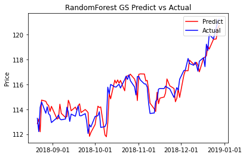

```python
print(grid_search_RF_feat.best_params_)
validate_result(grid_search_RF_feat,'RandomForest GS')
```

Random Forest with default parameters performed better than tuned Random Forest model. So, we will include random forest with default parameters as our second solution model.

```python
solution_models['Random_Forest with Feat'] = random_forest_clf_feat
```

### Lasso and Ridge

```
RMSE:  0.7117047240324096
R2 score:  0.8833324203076949
```

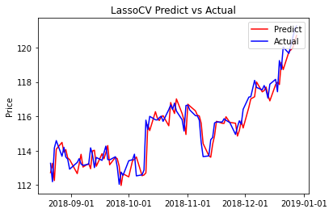

```
RMSE:  0.7186272522442692
R2 score:  0.8810518047982898
```

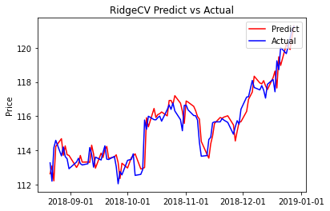

```python
from sklearn.linear_model import LassoCV
from sklearn.linear_model import RidgeCV

lasso_clf = LassoCV(n_alphas=1000, max_iter=3000, random_state=0)
ridge_clf = RidgeCV(gcv_mode='auto')

lasso_clf_feat = lasso_clf.fit(X_train,y_train)
validate_result(lasso_clf_feat,'LassoCV')
solution_models['LassoCV All feat'] = lasso_clf_feat

ridge_clf_feat = ridge_clf.fit(X_train,y_train)
validate_result(ridge_clf_feat,'RidgeCV')
solution_models['RidgeCV All Feat'] = ridge_clf_feat
```

### Bayesian Ridge

```
RMSE:  0.7195639601747041
R2 score:  0.8807415122691657
```

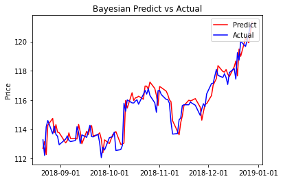

```python
from sklearn import linear_model
bay = linear_model.BayesianRidge()
bay_feat = bay.fit(X_train,y_train)
validate_result(bay_feat,'Bayesian')
solution_models['Bay All Feat'] = bay_feat
```

### Gradient Boosting Regressor

```
RMSE:  0.8094931831292806
R2 score:  0.8490695443986875
```

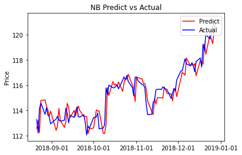

```python
from sklearn.ensemble import GradientBoostingRegressor
regr =GradientBoostingRegressor(n_estimators=70, learning_rate=0.1,max_depth=4, random_state=0, loss='ls')
GB_feat = regr.fit(X_train,y_train)
validate_result(GB_feat,'NB')
solution_models['GB All Feat'] = GB_feat
```

### Stochastic Gradient Descent (SGD)

```
RMSE:  0.9260973693042674
R2 score:  0.8024560231963879
```

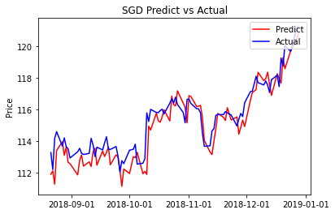

```python
from sklearn.linear_model import SGDRegressor
sgd =SGDRegressor(max_iter=1000, tol=1e-3,loss='squared_epsilon_insensitive',penalty='l1',alpha=0.1)
sgd_feat = sgd.fit(X_train,y_train)
validate_result(sgd_feat,'SGD')
solution_models['SGD All Feat'] = sgd_feat
```

### Model Review

Here we will review all the models based on evaluation metrics, i.e, RMSE and R2 score

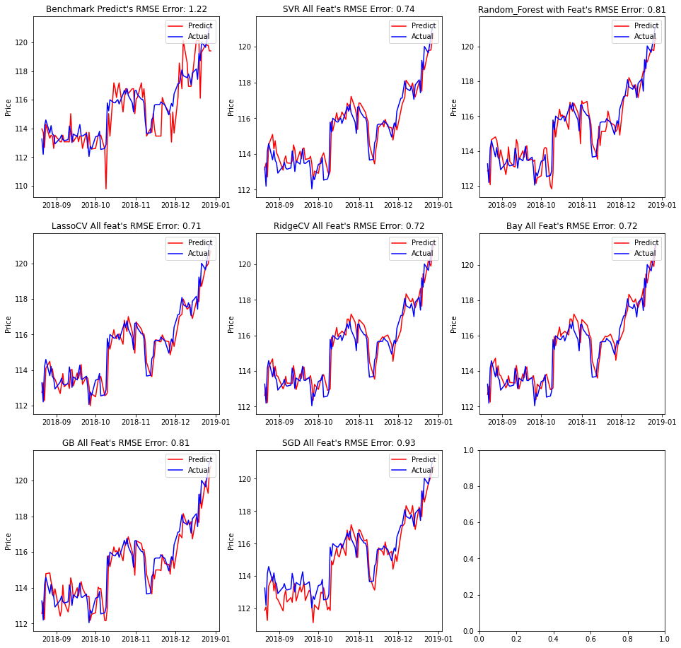

```python
RMSE_scores = {}
def model_review(models):
    fig, axes = plt.subplots(nrows=3, ncols=3, figsize=(16, 16))

    #plot benchmark model
    benchmark_predicted = benchmark_dt.predict(validation_X)
    benchmark_RSME_score = np.sqrt(mean_squared_error(validation_y, benchmark_predicted))
    RMSE_scores['Benchmark'] = benchmark_RSME_score

    axes[0,0].plot(validation_y.index, benchmark_predicted,'r', label='Predict')
    axes[0,0].plot(validation_y.index, validation_y,'b', label='Actual')
    axes[0,0].xaxis.set_major_formatter(mdates.DateFormatter('%Y-%m'))
    axes[0,0].xaxis.set_major_locator(mdates.MonthLocator())
    axes[0,0].set_ylabel('Price')
    axes[0,0].set_title("Benchmark Predict's RMSE Error: " +"{0:.2f}".format(benchmark_RSME_score))
    axes[0,0].legend(loc='upper right')

    #plot block
    ax_x = 0
    ax_y = 1
    #plot solution model
    for name, model in models.items():
        predicted = model.predict(validation_X)
        RSME_score = np.sqrt(mean_squared_error(validation_y, predicted))


        axes[ax_x][ax_y].plot(validation_y.index, predicted,'r', label='Predict')
        axes[ax_x][ax_y].plot(validation_y.index, validation_y,'b', label='Actual')
        axes[ax_x][ax_y].xaxis.set_major_formatter(mdates.DateFormatter('%Y-%m'))
        axes[ax_x][ax_y].xaxis.set_major_locator(mdates.MonthLocator())
        axes[ax_x][ax_y].set_ylabel('Price')
        axes[ax_x][ax_y].set_title(name + "'s RMSE Error: " +"{0:.2f}".format(RSME_score))
        axes[ax_x][ax_y].legend(loc='upper right')
        RMSE_scores[name] = RSME_score
        if ax_x <=2:
            if ax_y < 2:
                ax_y += 1
            else:
                ax_x += 1
                ax_y = 0
    plt.show()

model_review(solution_models)
```

### Comparison of RMSE of all models

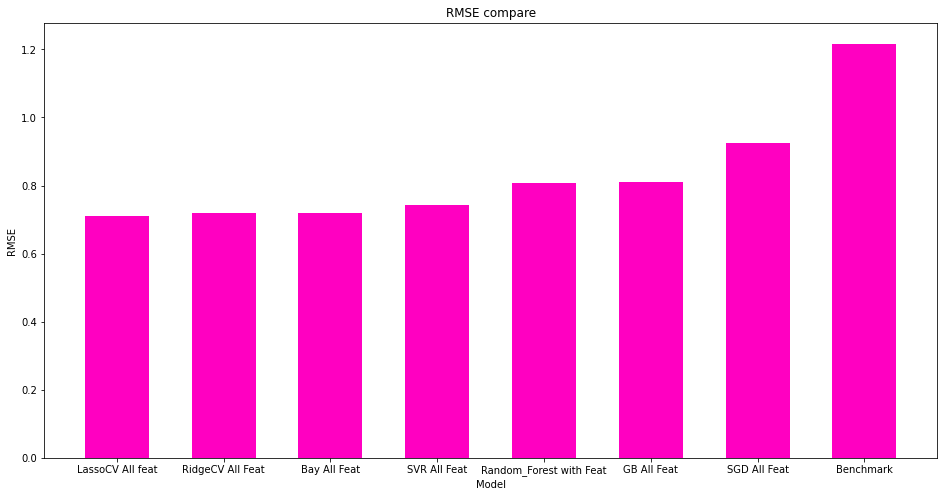

```python
model_names = []
model_values = []
for name, value in RMSE_scores.items():
    model_names.append(name)
    model_values.append(value)

model_values = np.array(model_values)
model_names = np.array(model_names)

indices = np.argsort(model_values)
columns = model_names[indices[:8]]
values = model_values[indices][:8]

fig = plt.figure(figsize = (16,8))
plt.bar(np.arange(8), values ,width = 0.6, align="center", color = '#ff00c1')
plt.xticks(np.arange(8), columns)
plt.xlabel('Model')
plt.ylabel('RMSE')
plt.title('RMSE compare')
plt.show()
```

### Feature Selection

We will select supporting features using sklearn's SelectFromModel library usig Lasso Regressor as it has lowest RMSE

```python
from sklearn.feature_selection import SelectFromModel

sfm = SelectFromModel(lasso_clf_feat)
sfm.fit(feature_minmax_transform, target_adj_close.values.ravel())
display(feature_minmax_transform.head())
sup = sfm.get_support()
zipped = zip(feature_minmax_transform,sup)
print(*zipped)
```

| Date | Open | High | Low | Volume | SP_open | SP_high | SP_low | SP_Ajclose | SP_volume | DJ_open | ... | USO_Volume | SMA | Upper_band | Lower_band | DIF | MACD | RSI | STDEV | Open_Close | High_Low |
| --- | --- | --- | --- | --- | --- | --- | --- | --- | --- | --- | --- | --- | --- | --- | --- | --- | --- | --- | --- | --- | --- |
| 2012-02-06 | 0.913669 | 0.912561 | 0.913193 | 0.079151 | 0.037098 | 0.034927 | 0.040627 | 0.028113 | 0.166542 | 0.051563 | ... | 0.046608 | 0.906189 | 0.961240 | 0.821988 | 0.893394 | 0.911893 | 0.807275 | 0.167603 | 0.415010 | 0.091684 |
| 2012-02-07 | 0.919480 | 0.945539 | 0.920622 | 0.109560 | 0.038247 | 0.038015 | 0.039473 | 0.029765 | 0.224602 | 0.050453 | ... | 0.084243 | 0.916193 | 0.965092 | 0.837893 | 0.896986 | 0.915193 | 0.852413 | 0.171198 | 0.280308 | 0.291045 |
| 2012-02-08 | 0.945490 | 0.943760 | 0.925437 | 0.099173 | 0.042423 | 0.039225 | 0.043542 | 0.031707 | 0.232599 | 0.051907 | ... | 0.073338 | 0.923859 | 0.965108 | 0.853105 | 0.885164 | 0.914871 | 0.798744 | 0.169132 | 0.477870 | 0.239873 |
| 2012-02-09 | 0.955866 | 0.949370 | 0.927775 | 0.157998 | 0.045752 | 0.041465 | 0.045060 | 0.032533 | 0.251876 | 0.053171 | ... | 0.033218 | 0.930011 | 0.964000 | 0.866467 | 0.867900 | 0.910578 | 0.777317 | 0.100533 | 0.556766 | 0.265458 |
| 2012-02-10 | 0.907167 | 0.912014 | 0.909341 | 0.095612 | 0.038187 | 0.034685 | 0.040687 | 0.027676 | 0.292146 | 0.053519 | ... | 0.045532 | 0.935684 | 0.958155 | 0.883757 | 0.842920 | 0.901486 | 0.737688 | 0.111185 | 0.387428 | 0.117271 |

5 rows × 84 columns

[output not shown]

```python
# Selecting Features which supports Model building process

feature_selected = feature_minmax_transform[['Open','High','Low','OF_Trend','USB_Trend','PLT_Trend','USDI_Price','GDX_Close','SMA','Upper_band','RSI','Open_Close']]
feature_selected_validation_X = validation_X[['Open','High','Low','OF_Trend','USB_Trend','PLT_Trend','USDI_Price','GDX_Close','SMA','Upper_band','RSI','Open_Close']]
display(feature_selected.head())
display(feature_selected_validation_X.head())
```

| Date | Open | High | Low | OF_Trend | USB_Trend | PLT_Trend | USDI_Price | GDX_Close | SMA | Upper_band | RSI | Open_Close |
| --- | --- | --- | --- | --- | --- | --- | --- | --- | --- | --- | --- | --- |
| 2012-02-06 | 0.913669 | 0.912561 | 0.913193 | 1.0 | 0.0 | 0.0 | 0.035457 | 0.974365 | 0.906189 | 0.961240 | 0.807275 | 0.415010 |
| 2012-02-07 | 0.919480 | 0.945539 | 0.920622 | 1.0 | 1.0 | 1.0 | 0.015007 | 0.967677 | 0.916193 | 0.965092 | 0.852413 | 0.280308 |
| 2012-02-08 | 0.945490 | 0.943760 | 0.925437 | 1.0 | 1.0 | 1.0 | 0.017368 | 0.960098 | 0.923859 | 0.965108 | 0.798744 | 0.477870 |
| 2012-02-09 | 0.955866 | 0.949370 | 0.927775 | 1.0 | 1.0 | 0.0 | 0.014087 | 0.953633 | 0.930011 | 0.964000 | 0.777317 | 0.556766 |
| 2012-02-10 | 0.907167 | 0.912014 | 0.909341 | 0.0 | 0.0 | 1.0 | 0.037058 | 0.936692 | 0.935684 | 0.958155 | 0.737688 | 0.387428 |

| Date | Open | High | Low | OF_Trend | USB_Trend | PLT_Trend | USDI_Price | GDX_Close | SMA | Upper_band | RSI | Open_Close |
| --- | --- | --- | --- | --- | --- | --- | --- | --- | --- | --- | --- | --- |
| 2018-08-21 | 0.163946 | 0.165709 | 0.167974 | 1.0 | 1.0 | 0.0 | 0.674324 | 0.143781 | 0.169137 | 0.179197 | 0.312663 | 0.413085 |
| 2018-08-22 | 0.172524 | 0.171045 | 0.176640 | 1.0 | 0.0 | 0.0 | 0.670362 | 0.146901 | 0.166531 | 0.173311 | 0.340181 | 0.436818 |
| 2018-08-23 | 0.162701 | 0.162698 | 0.162746 | 0.0 | 1.0 | 0.0 | 0.691652 | 0.133526 | 0.163714 | 0.170454 | 0.271060 | 0.459910 |
| 2018-08-24 | 0.170587 | 0.183771 | 0.178566 | 1.0 | 0.0 | 1.0 | 0.670842 | 0.144449 | 0.163369 | 0.169642 | 0.456216 | 0.370750 |
| 2018-08-27 | 0.182623 | 0.188697 | 0.191085 | 1.0 | 1.0 | 1.0 | 0.655675 | 0.151806 | 0.163053 | 0.168648 | 0.490053 | 0.398974 |

### Train Test Split

```python
 for train_index, test_index in ts_split.split(feature_selected):
        X_train, X_test = feature_selected[:len(train_index)], feature_selected[len(train_index): (len(train_index)+len(test_index))]
        y_train, y_test = target_adj_close[:len(train_index)].values.ravel(), target_adj_close[len(train_index): (len(train_index)+len(test_index))].values.ravel()
```

#### Validation feature selected model

```python
def feature_selected_validate_result(model, model_name):
    predicted = model.predict(feature_selected_validation_X)

    RSME_score = np.sqrt(mean_squared_error(validation_y, predicted))
    R2_score = r2_score(validation_y, predicted)

    print(model_name + '\n')
    print('RMSE: ', RSME_score)
    print('R2 score: ', R2_score)
    print('----------------------')


print('---------Benchmark-------------')
dt = DecisionTreeRegressor(random_state=0)
benchmark_dt_fs = dt.fit(X_train,y_train)
feature_selected_validate_result(benchmark_dt_fs, 'Decision Tree')

feature_selected_solution_models = {}

print('--------Solution Models--------------')
# Random Forest
random_forest_clf_fs = RandomForestRegressor(random_state=0,
                                             max_depth=3,
                                             max_features='auto',
                                             n_estimators=10
)
random_forest_parameters = {
    'n_estimators':[10, 50, 100],
    'max_features':['auto','sqrt','log2'],
    'max_depth':[3, 5, 7],
}
grid_search_RF_fs = GridSearchCV(estimator=random_forest_clf_fs,
                           param_grid=random_forest_parameters,
                           cv=ts_split,
)
grid_search_RF_fs.fit(X_train, y_train)
feature_selected_validate_result(grid_search_RF_fs,'Feature selected RandomForest GS')
feature_selected_solution_models['FS_RandomForest'] = grid_search_RF_fs

# Linear SVR
linear_svr_fs = SVR(
                          C=50.0,
                          epsilon=0,kernel='linear')
linear_svr_clf_fs = linear_svr_fs.fit(X_train,y_train)
feature_selected_validate_result(linear_svr_clf_fs,'Feature selected LSVR')
feature_selected_solution_models['FS_LSVR'] = linear_svr_clf_fs


# lasso
lasso_fs = LassoCV(n_alphas=1000, max_iter=3000, random_state=0)
lasso_clf_fs = lasso_fs.fit(X_train,y_train)
feature_selected_validate_result(lasso_clf_fs,'Feature selected LassoCV')
feature_selected_solution_models['FS_Lasso'] = lasso_clf_fs

# Ridge
ridge_fs = RidgeCV(gcv_mode='auto')
ridge_clf_fs = ridge_fs.fit(X_train,y_train)
feature_selected_validate_result(ridge_clf_fs,'Feature selected RidgeCV')
feature_selected_solution_models['FS_RidgeCV'] = ridge_clf_fs

# bayesian ridge
bay = linear_model.BayesianRidge()
bay_feat_fs = bay.fit(X_train,y_train)
feature_selected_validate_result(bay_feat_fs,'Feature selected BayRidge')
feature_selected_solution_models['Bay_Ridge'] = bay_feat_fs

#Gradient Boosting
regr =GradientBoostingRegressor(n_estimators=70, learning_rate=0.1,max_depth=4, random_state=0, loss='ls')
GB_fs = regr.fit(X_train,y_train)
feature_selected_validate_result(GB_fs,'Feature selected GB')
feature_selected_solution_models['GB_FS'] = GB_fs

#SGD

sgd =SGDRegressor(max_iter=1000, tol=1e-3,loss='squared_epsilon_insensitive',penalty='l1',alpha=0.1)
sgd_fs = sgd.fit(X_train,y_train)
feature_selected_validate_result(sgd_fs,'Feature selected SGD')
feature_selected_solution_models['sgd_fs'] = sgd_fs
```

```
---------Benchmark-------------
Decision Tree

RMSE:  1.3140710969641578
R2 score:  0.6022701215418467
----------------------
--------Solution Models--------------
Feature selected RandomForest GS

RMSE:  0.8052237275992113
R2 score:  0.850657430616824
----------------------
Feature selected LSVR

RMSE:  0.7160621902397207
R2 score:  0.8818994346855501
----------------------
Feature selected LassoCV

RMSE:  0.709253800299422
R2 score:  0.8841345815790793
----------------------
Feature selected RidgeCV

RMSE:  0.717925484828007
R2 score:  0.8812840064287453
----------------------
Feature selected BayRidge

RMSE:  0.7125419009132461
R2 score:  0.8830577871838711
----------------------
```

```
Feature selected GB

RMSE:  0.8223529442134774
R2 score:  0.8442360346752706
----------------------
Feature selected SGD

RMSE:  0.7661874718781764
R2 score:  0.8647863351187786
----------------------
```